# MI Gibbs sampler with 2 correlated covariates

Callum Doyle

2025-12-10

This file reproduces the Multiple Imputation for left-censored and correlated data as described in (Lee et al., 2012).

Before we get started with implementing the method, we need some data to practice on.

### Generate the data

Create a function to generate bivariate normal left censored data with a desired censoring rate `cens.pct`.

```r
f.datGen.BVNleftcens <- function(nn, mu.1, mu.2, Sigma.y, cens.pct = c(4,4)){
  ## GENERATE LEFT-CENSORED BVN DATA --- --- --- --- --- --- --- --- --- --- --- --- --- --- --- --- --- --- --- ---
  YY <- MASS::mvrnorm(nn, c(0,0), Sigma.y) + cbind(mu.1, mu.2) # correlated biomarkers
  YY <- as.data.frame(YY)
  colnames(YY) <- c('y1','y2')
  colMeans(YY); cor(YY)

  #### LEFT CENSOR THE DATA ####

  ## set limits of detection
  # cens.pct <- c(4,4) # censoring percentage (i.e., get the 40th percentile)
  lod.1 <- quantile(YY$y1, 1:10/10)[cens.pct[1]] # censor at percentile
  lod.2 <- quantile(YY$y2, 1:10/10)[cens.pct[2]] # censor at percentile

  ## left censor data
  YY$y1.obs <- pmax(YY$y1, lod.1)
  YY$y2.obs <- pmax(YY$y2, lod.2)

  ## censoring indicator, 1 if censored (below lod), 0 if observed (above lod)
  YY$cens.1 <- 1*(YY$y1.obs==lod.1)
  YY$cens.2 <- (1*(YY$y2.obs==lod.2))

  ## naive lod/2
  YY$y1.half.lod <- ifelse(YY$cens.1==1, lod.1/2, YY$y1)
  YY$y2.half.lod <- ifelse(YY$cens.2==1, lod.2/2, YY$y2)

  return(YY)
}
```

Define variables to generate the data from a bivariate normal distribution with means $\mu_1 = 1, \mu_2=2$ with categorical covariate $X_1$.

```r
set.seed(10)
nn <- 300

## coefficient and covariate for biomarker
x1 <- sample(0:1, nn, T)
XX <- model.matrix(~ x1) # design matrix
Beta1 <- c(0.5,1) # produces mean 1
Beta2 <- c(1.5,1) # produces mean 2

## means of each biomarker
mu.1 <- XX %*% Beta1
mu.2 <- XX %*% Beta2
rho <- 0.5 # correlation
Sigma.y <- diag(1-rho, 2) + rho # covariance matrix
YY <- f.datGen.BVNleftcens(nn, mu.1, mu.2, Sigma.y, cens.pct = c(4,4))
round(head(YY, 10),3)
```

```
##        y1     y2 y1.obs y2.obs cens.1 cens.2 y1.half.lod y2.half.lod
## 1  -0.421  1.743  0.804  1.743      1      0       0.402       1.743
## 2   1.045  0.522  1.045  1.735      0      1       1.045       0.867
## 3   3.760  2.241  3.760  2.241      0      0       3.760       2.241
## 4   1.105  1.397  1.105  1.735      0      1       1.105       0.867
## 5   0.893  1.606  0.893  1.735      0      1       0.893       0.867
## 6  -1.292 -0.728  0.804  1.735      1      1       0.402       0.867
## 7   2.199  2.856  2.199  2.856      0      0       2.199       2.856
## 8   2.516  3.476  2.516  3.476      0      0       2.516       3.476
## 9  -0.982  0.905  0.804  1.735      1      1       0.402       0.867
## 10 -0.688 -0.048  0.804  1.735      1      1       0.402       0.867
```

### Model Inputs and Hyperparameters

Specify necessary inputs for the Gibbs sampler:
$$\Sigma \sim \mathrm{InvWishart}(\nu_0,
S_0),$$
$$\beta_j \sim MVN(\beta_{0j},
\Omega = \sigma^2_j B_0).$$
That is, assign the covariance matrix an Inverse Wishart prior and the beta coefficients matrix normal where each column is multivariate normal.

```r
## Hyperparameters for covariance matrix prior:
nu0.Sigma <- 4                 # df Inv-Wishart
S0.Sigma  <- diag(2) + 0.2     # scale matrix (weak correlation prior)

## Hyperparameters for regression coefficients:
beta1.0   <- c(0,0,0)          # prior mean for beta_y1
covB.1.0  <- diag(1,3)         # prior covariance for beta_y1
beta2.0   <- c(0,0,0)          # prior mean for beta_y2
covB.2.0  <- diag(1,3)         # prior covariance for beta_y2

## LODs
lod.1 <- min(YY$y1.half.lod * 2)
lod.2 <- min(YY$y2.half.lod * 2)
```

The outcome of interest $Z$ is generated from a logistic regression based on the true biomarker values:
$$\text{logit}\{\Pr(Z=1)\} = b_0 + b_1 y_1 + b_2 y_2.$$

```r
## Set the true b coefficients for outcome of interest
bb <- c(-0.1, -0.2, 0.3)

design.mat.Y <- model.matrix(~ y1 + y2, data = YY)
logit.p <- design.mat.Y %*% bb # logit(Pr(Y=1)), logit model describes linear relationship
pp <- 1/(1+exp(-logit.p))
nn <- nrow(YY)
zz <- rbinom(nn, 1, pp) # outcome of interest
```

Also, previous research shows that all available information, i.e., including the outcome, should be used when imputing missing values.

```r
## update design matrix so imputation accounts for the outcome of interest.
XXz <- cbind(XX,zz)
```

### Initialise sampler

Begin with sampling the covariance matrix from inverse-wishart $(\nu_0, S_0)$ and extract the variance components and correlation

```r
## covariance matrix and extract components.
Sig.init <- MCMCpack::riwish(nu0.Sigma, S0.Sigma)
sig2.y1.init <- as.numeric(Sig.init[1,1])
sig2.y2.init <- as.numeric(Sig.init[2,2])
rho.init <- as.numeric(Sig.init[1,2] / sqrt(sig2.y1.init*sig2.y2.init))
```

Recall that the mean, conditioned on the variance, is multivariate normal with covariance matrix $\Omega$. We compute this and then sample the prior MVN random variables for our initial mean vectors for each biomarker.

```r
## prior covariance matrix for the prior mean vector.
Omega1.0 <- sig2.y1.init * covB.1.0
Omega2.0 <- sig2.y2.init * covB.2.0

## beta1 for y1
beta.y1.init <- MASS::mvrnorm(n=1, mu = beta1.0, Sigma = Omega1.0)

## beta2 for y2
beta.y2.init <- MASS::mvrnorm(n=1, mu = beta2.0, Sigma = Omega2.0)
```

We are almost ready to run the Gibbs sampler; set up matrices to keep track of each iteration, since we want to extract $M$ datasets to perform MI analysis.

```r
## num iterations
n.mcmc <- 5000
## set up samples dataframe and biomarker matrix to keep track of each loop
yy1.complete <- YY$y1.obs
yy2.complete <- YY$y2.obs
dat.length <- length(yy2.complete)

## data matrix for imputated y1 and y2 biomarkers
yy1.dat <- yy2.dat <- matrix(NA, nrow = dat.length, ncol = n.mcmc + 1)
yy1.dat[,1] <- yy1.complete # observed data is initial
yy2.dat[,1] <- yy2.complete # observed data is initial

## parameter matrix for updated params
samples <- data.frame(
  iteration = 0:n.mcmc,
  y1.beta1 = NA,
  y1.beta2 = NA,
  y1.beta3 = NA,
  y1.sigma2 = NA,
  y2.beta1 = NA,
  y2.beta2 = NA,
  y2.beta3 = NA,
  y2.sigma2 = NA,
  rho = NA
)
samples[1,2:10] <- c(beta.y1.init[1], beta.y1.init[2], beta.y1.init[3], sig2.y1.init,
                     beta.y2.init[1], beta.y2.init[2], beta.y2.init[3], sig2.y2.init, rho.init) # initials

## initialise params for r-th iteration
beta.y1.r <- beta.y1.init
beta.y2.r <- beta.y2.init

##
Sigma.r <- Sig.init
sig2.y1.r <- sig2.y1.init
sig2.y2.r <- sig2.y2.init
rho.r <- rho.init
```

The last piece of bookkeeping involves the censoring patterns; get the index for which biomarkers to impute based on the censoring pattern so the Gibbs sampler knows what to do.

```r
## index of censored biomarkers to impute, based on censoring pattern
#' imputed censored values via conditional normal distribution
#' pattern 1 := p1. both y1,y2 observed. (do nothing)
#' pattern 2 := p2. y1 observed, y2 censored.
#' pattern 3 := p3. y1 censored, y2 observed.
#' pattern 4 := p4. both y1,y2 censored.
cens.idx.p1 <- which(YY$cens.1==0 & YY$cens.2==0)
cens.idx.p2 <- which(YY$cens.1==0 & YY$cens.2==1)
cens.idx.p3 <- which(YY$cens.1==1 & YY$cens.2==0)
cens.idx.p4 <- which(YY$cens.1==1 & YY$cens.2==1)
```

### Gibbs sampler

The sampling algorithm is as follows.

```r
## begin loop
  for(i in 1:n.mcmc){

    ## Impute censored biomarkers, sample from truncated normal --- --- --- --- --- --- --- --- --- --- --- ---
    y1.XB.r <- as.numeric(XXz %*% beta.y1.r)
    y2.XB.r <- as.numeric(XXz %*% beta.y2.r)

    #### PATTERN 2 : y1 observed, y2 censored. Impute y2 based conditional (truncated) normal dist ####
    if(length(cens.idx.p2) > 0) {
    mean.p2 <- y2.XB.r[cens.idx.p2] + (rho.r * sqrt(sig2.y2.r / sig2.y1.r)) * (yy1.complete[cens.idx.p2] - y1.XB.r[cens.idx.p2])
    var.p2 <- sig2.y2.r * (1- rho.r^2)
    yy2.imputed.p2 <- bayesm::rtrun(mean.p2,
                                    rep(sqrt(var.p2), length(cens.idx.p2)),
                                    a = c(rep(-1e8, length(cens.idx.p2))),
                                    b = c(rep(lod.2, length(cens.idx.p2))))
    yy2.complete[cens.idx.p2] <- yy2.imputed.p2
    }

    #### PATTERN 3 : y1 censored, y2 observed. Impute y1 based conditional (truncated) normal dist ####
    if(length(cens.idx.p3) > 0) {
    mean.p3 <- y1.XB.r[cens.idx.p3] + (rho.r * sqrt(sig2.y1.r / sig2.y2.r)) * (yy2.complete[cens.idx.p3] - y2.XB.r[cens.idx.p3])
    var.p3 <- sig2.y1.r * (1- rho.r^2)
    yy1.imputed.p3 <- bayesm::rtrun(mean.p3,
                                    rep(sqrt(var.p3), length(cens.idx.p3)),
                                    a = c(rep(-1e8, length(cens.idx.p3))),
                                    b = c(rep(lod.1, length(cens.idx.p3))))
    yy1.complete[cens.idx.p3] <- yy1.imputed.p3
    }

    #### PATTERN 4 : both y1 and y2 are censored. Impute one at a time using previous value. ####
    if(length(cens.idx.p4) > 0) {
    ## first, impute y1 conditional on previous y2.
    mean.y1.p4 <- y1.XB.r[cens.idx.p4] + (rho.r * sqrt(sig2.y1.r / sig2.y2.r)) * (yy2.complete[cens.idx.p4] - y2.XB.r[cens.idx.p4])
    var.y1.p4 <- sig2.y1.r * (1- rho.r^2)
    yy1.imputed.p4 <- bayesm::rtrun(mean.y1.p4,
                                    rep(sqrt(var.y1.p4), length(cens.idx.p4)),
                                    a = c(rep(-1e8, length(cens.idx.p4))),
                                    b = c(rep(lod.1, length(cens.idx.p4))))
    yy1.complete[cens.idx.p4] <- yy1.imputed.p4

    ## second, impute y2 conditional on newly imputed y1.
    mean.y2.p4 <- y2.XB.r[cens.idx.p4] + (rho.r * sqrt(sig2.y2.r / sig2.y1.r)) * (yy1.complete[cens.idx.p4] - y1.XB.r[cens.idx.p4])
    var.y2.p4 <- sig2.y2.r * (1- rho.r^2)
    yy2.imputed.p4 <- bayesm::rtrun(mean.y2.p4,
                                    rep(sqrt(var.y2.p4), length(cens.idx.p4)),
                                    a = c(rep(-1e8, length(cens.idx.p4))),
                                    b = c(rep(lod.2, length(cens.idx.p4))))
    yy2.complete[cens.idx.p4] <- yy2.imputed.p4
    }

    ## PARAMETER UPDATES --- --- --- --- --- --- --- --- --- --- --- --- --- --- --- --- --- ---

    ## update covariance matrix Sigma from inverse wishart
    updated.df <- nu0.Sigma + dat.length
    residual.mat <- cbind(yy1.complete - y1.XB.r, yy2.complete - y2.XB.r) # matrix of (Y - theta)
    updated.scale.mat <- S0.Sigma + crossprod(residual.mat) # (Y-theta)^T %*% (Y-theta)
    Sigma.r <- MCMCpack::riwish(updated.df, updated.scale.mat)

    ## update variance params and correlation from the covariance matrix
    sig2.y1.r <- as.numeric(Sigma.r[1,1])
    sig2.y2.r <- as.numeric(Sigma.r[2,2])
    rho.r <- as.numeric(Sigma.r[1,2] / sqrt(sig2.y1.r*sig2.y2.r))

    ## update parameters: sample beta for y1
    updated.y1.cov.r <- solve((crossprod(XXz,XXz)/sig2.y1.r) + solve(Omega1.0))
    updated.y1.mean.r <- updated.y1.cov.r %*% ((crossprod(XXz,yy1.complete) / sig2.y1.r) + (solve(Omega1.0) %*% beta1.0))
    beta.y1.r <- MASS::mvrnorm(n=1, mu = updated.y1.mean.r,
                               Sigma = updated.y1.cov.r)

    ## update parameters: sample beta for y2
    updated.y2.cov.r <- solve((crossprod(XXz,XXz)/sig2.y2.r) + solve(Omega2.0))
    updated.y2.mean.r <- updated.y2.cov.r %*% ((crossprod(XXz,yy2.complete) / sig2.y2.r) + (solve(Omega2.0) %*% beta2.0))
    beta.y2.r <- MASS::mvrnorm(n=1, mu = updated.y2.mean.r,
                             Sigma = updated.y2.cov.r)

    ## update samples matrix and imputed dataset --- --- --- --- --- --- --- --- --- --- --- ---
    yy1.dat[,i+1] <- yy1.complete
    yy2.dat[,i+1] <- yy2.complete
    samples[i+1, 2:10] <- c(beta.y1.r[1], beta.y1.r[2], beta.y1.r[3], sig2.y1.r,
                           beta.y2.r[1], beta.y2.r[2], beta.y2.r[3], sig2.y2.r, rho.r)
  } # END OF GIBBS SAMPLER LOOP --- --- --- --- --- --- --- --- --- --- --- --- --- --- --- --- --- ---
```

### Diagnostics

Traceplots look ok.

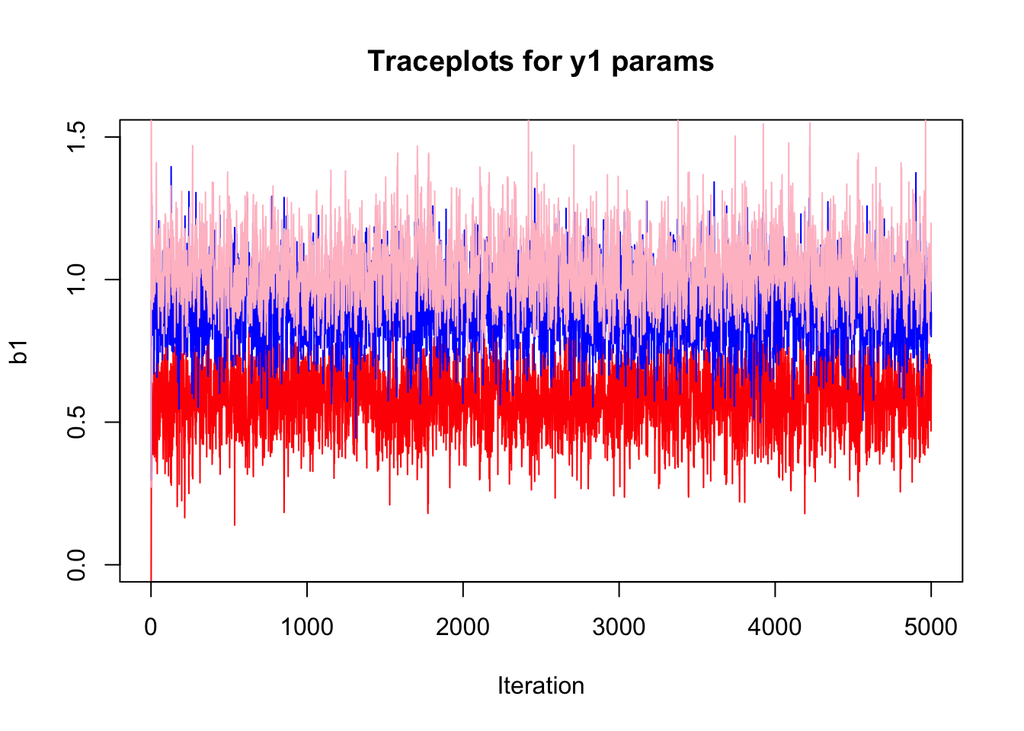

```r
# traceplots
 plot(samples$y1.beta1, type = 'l', col = 'red',
      main = 'Traceplots for y1 params', xlab = 'Iteration', ylab = 'b1', ylim = c(0,1.5))
 lines(samples$y1.beta2, type = 'l', col = 'blue')
 lines(samples$y1.sigma2, type='l', col= 'pink')
```

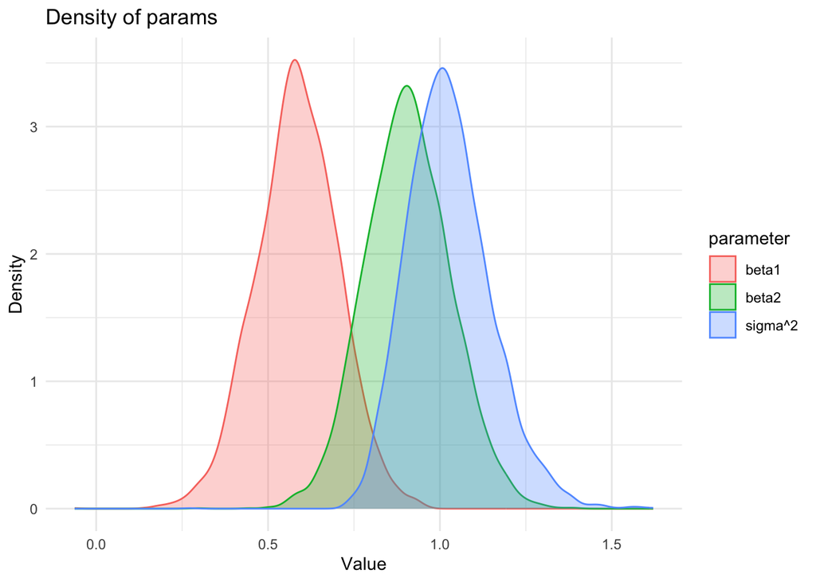

```r
 ## plot the posterior density
 foo.df <- with(samples, data.frame(
   value = c(y1.beta1, y1.beta2, y1.sigma2),
   parameter = rep(c("beta1", "beta2", "sigma^2"),
                   each = length(iteration))
 ))
 ggplot(foo.df, aes(x = value, color = parameter, fill = parameter)) +
   geom_density(alpha = 0.3) +   # transparency
   labs(title = "Density of params",
        x = "Value", y = "Density") +
   theme_minimal()
```

### Multiple imputation analysis

In this case, we let $M=5$ and take datasets $1000,2000,3000,4000$, and $5000$ and we compare to the naive and omniscient estimates.

```r
MI.coef <- sapply(seq(from=1000, to=5000, length.out=5),
                    FUN = function(jj){
                      y1.tmp <- yy1.dat[,jj]
                      y2.tmp <- yy2.dat[,jj]
                      fit <- glm(zz ~ y1.tmp + y2.tmp, data = YY, family = binomial)
                      c(summary(fit)$coef[1:3,1:2])
                    })
  rownames(MI.coef) <- c('mu.b0', 'mu.b1', 'mu.b2', 'se.b0', 'se.b1', 'se.b2')
  mi.betas <- MI.coef[1:3,]
  mi.se <- MI.coef[4:6,]

  ## MI mean
  pooled.beta <- rowMeans(mi.betas)

  ## MI variance (Little and Rubin 2015 pp.234)
  within.var <- rowMeans(mi.se^2)
  between.var <- apply(mi.betas, 1, var) # (1/(ncol(mi.betas)-1))*sum((mi.betas[3,]- mean(mi.betas[3,]))^2)
  DD <- ncol(mi.se)
  pooled.se <- sqrt(within.var + (1 + 1/DD)*between.var)

  ## compute confidence intervals for coverage probability: t-based 95% CI (from Little and Rubin).
  deg.freedom <- (DD-1) * (1 + (DD/(DD+1)) * within.var/between.var)^2
  ci.lower.mi <- pooled.beta - qt(0.975, df = deg.freedom) * pooled.se
  ci.upper.mi <- pooled.beta + qt(0.975, df = deg.freedom) * pooled.se
  coverage.mi <- (bb >= ci.lower.mi) & (bb <= ci.upper.mi)

  #### OMNISCIENT #### --- --- --- --- --- --- --- --- --- --- --- --- --- --- --- --- --- --- --- --- --- --- --- ---
  true.fit <- glm(zz ~ y1 + y2, data = YY, family = binomial)
  ci.lower.omni <- coef(true.fit) - qnorm(0.975) * sqrt(diag(vcov(true.fit)))
  ci.upper.omni <- coef(true.fit) + qnorm(0.975) * sqrt(diag(vcov(true.fit)))
  coverage.omni <- (bb >= ci.lower.omni) & (bb <= ci.upper.omni)

  #### NAIVE LOD/2 #### --- --- --- --- --- --- --- --- --- --- --- --- --- --- --- --- --- --- --- --- --- --- --- ---
  naive.fit <- glm(zz ~ y1.half.lod + y2.half.lod, data = YY, family = binomial)
  ci.lower.naive <- coef(naive.fit) - qnorm(0.975) * sqrt(diag(vcov(naive.fit)))
  ci.upper.naive <- coef(naive.fit) + qnorm(0.975) * sqrt(diag(vcov(naive.fit)))
  coverage.naive <- (bb >= ci.lower.naive) & (bb <= ci.upper.naive)
```

### Results

View and compare results:

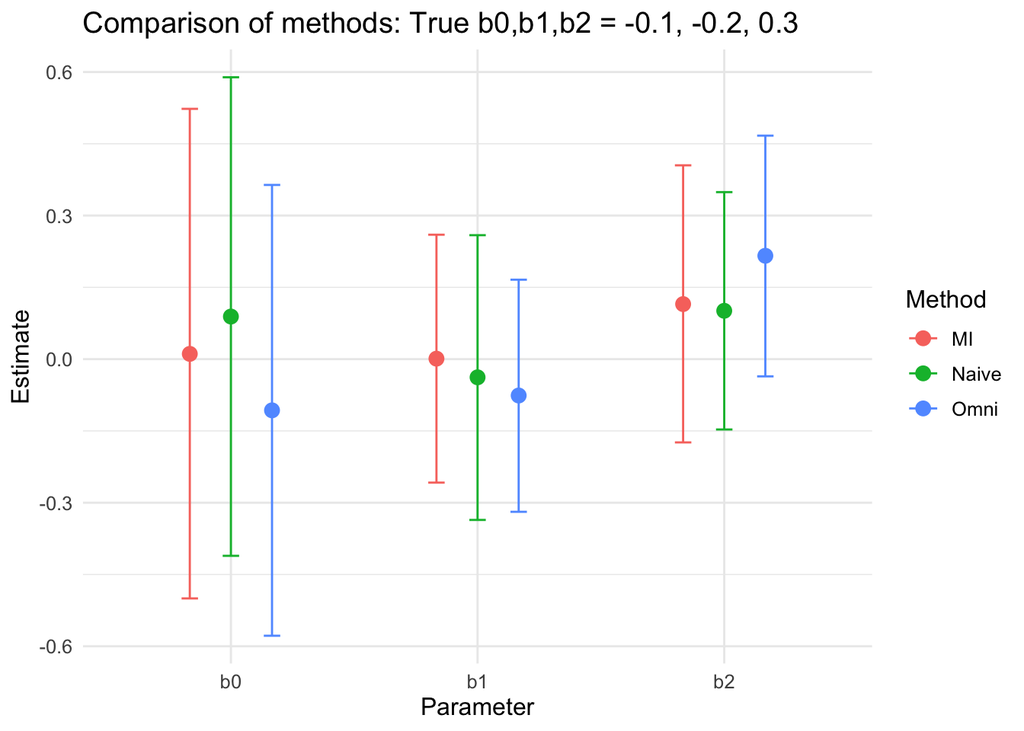